# I-SPY2 Radiogenomic Analysis

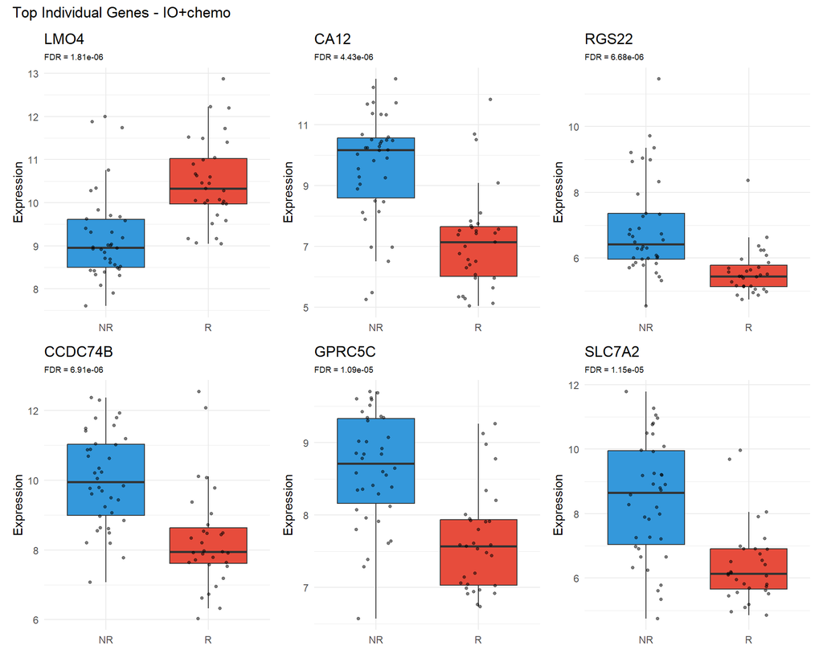

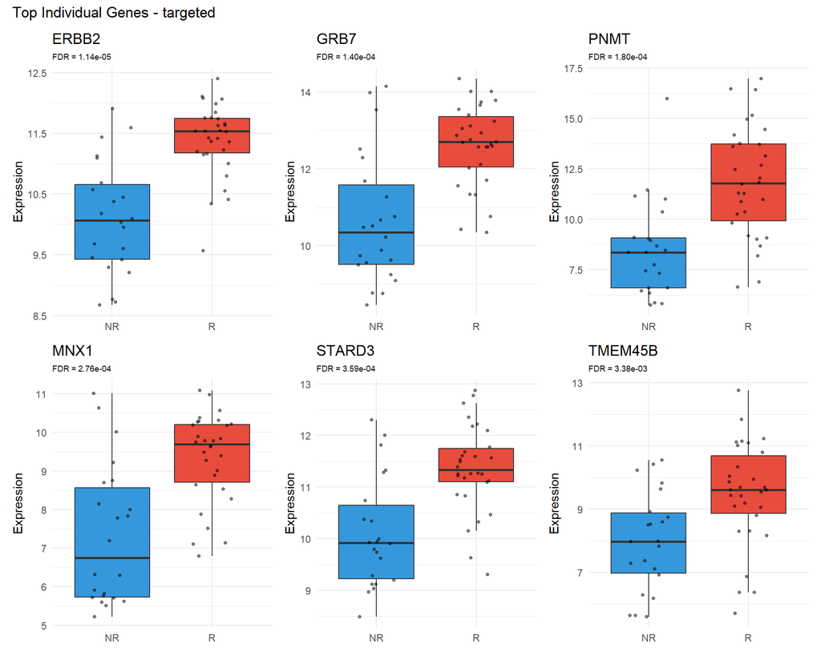

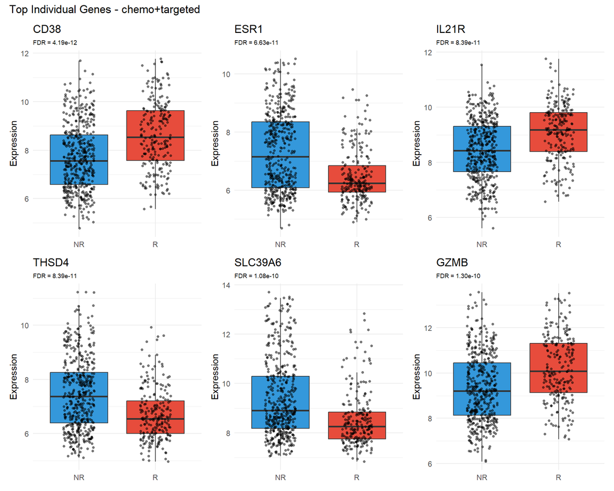

```r
for (treat in sub_treat) {
  top_genes_df <- gene_response_df %>%
    filter(Treatment == treat, FDR < 0.05) %>%
    head(6)

  if (nrow(top_genes_df) == 0) next

  clin_sub <- clin_data[clin_data$treatment == treat, ]
  ids <- clin_sub$patientid[clin_sub$patientid %in% colnames(expr_data)]

  plot_list <- list()
  for (j in seq_len(nrow(top_genes_df))) {
    gene <- top_genes_df$Gene[j]
    fdr_val <- top_genes_df$FDR[j]

    df <- data.frame(
      Expression = as.numeric(expr_data[gene, ids]),
      Response = clin_sub$response[clin_sub$patientid %in% ids]
    )
    plot_list[[gene]] <- ggplot(df, aes(x = Response, y = Expression, fill = Response)) +
      geom_boxplot(outlier.shape = NA) +
      geom_jitter(width = 0.2, alpha = 0.5, size = 1) +
      scale_fill_manual(values = c("R" = "#E74C3C", "NR" = "#3498DB")) +
      labs(title = gene,
           subtitle = paste0("FDR = ", formatC(fdr_val, format = "e", digits = 2)),
           y = "Expression", x = NULL) +
      theme_minimal() +
      theme(legend.position = "none",
            plot.subtitle = element_text(size = 7))
  }

  combined <- wrap_plots(plot_list, ncol = 3) +
    plot_annotation(title = paste("Top Individual Genes -", treat))
  print(combined)
}
```

#### Step 2: Data-Driven Gene Group Scores

Group candidate genes by biological function (from DE results in Section 6) and test combined z-score as a group signature.

```r
# Define gene groups from our DE results
immune_genes <- intersect(c("CD8A", "CD8B", "PDCD1", "CD274", "IFNG", "GZMB", "PRF1",
                             "CXCL9", "CXCL13", "IDO1", "LAMP3", "CCL13", "MARCO", "UBD",
                             "CHI3L2", "CRABP1", "KRT5"), candidate_genes)

luminal_genes <- intersect(c("ESR1", "PGR", "FOXA1", "GATA3", "AR", "AGR2", "CA12",
                              "TFF1", "TFF3", "SCUBE2", "ACOX2", "MSMB"), candidate_genes)

her2_genes <- intersect(c("ERBB2", "GRB7", "MNX1", "PNMT"), candidate_genes)

gene_groups <- list(
  Immune_Activation = immune_genes,
  Luminal_Resistance = luminal_genes,
  HER2_Associated = her2_genes
)
gene_groups <- gene_groups[sapply(gene_groups, length) >= 2]

cat("Gene groups:\n")
```

Gene groups:

```r
for (g in names(gene_groups)) {
  cat(" ", g, "(", length(gene_groups[[g]]), "genes):",
      paste(gene_groups[[g]], collapse = ", "), "\n")
}
```

Immune_Activation ( 17 genes): CD8A, CD8B, PDCD1, CD274, IFNG, GZMB, PRF1, CXCL9, CXCL13, IDO1, LAMP3, CCL13, MARCO, UBD, CHI3L2, CRABP1, KRT5 Luminal_Resistance ( 12 genes): ESR1, PGR, FOXA1, GATA3, AR, AGR2, CA12, TFF1, TFF3, SCUBE2, ACOX2, MSMB HER2_Associated ( 4 genes): ERBB2, GRB7, MNX1, PNMT

```r
# Test each group per treatment
group_results <- list()
for (group_name in names(gene_groups)) {
  genes <- gene_groups[[group_name]]
  for (treat in sub_treat) {
    clin_sub <- clin_data[clin_data$treatment == treat, ]
    ids <- clin_sub$patientid[clin_sub$patientid %in% colnames(expr_data)]

    z_mat <- t(scale(t(expr_data[genes, ids])))
    group_score <- colMeans(z_mat, na.rm = TRUE)
    response <- clin_sub$response[clin_sub$patientid %in% ids]

    wt <- wilcox.test(group_score ~ response)

    group_results[[paste(treat, group_name)]] <- data.frame(
      Treatment = treat, Gene_Group = group_name,
      n_genes = length(genes),
      genes = paste(genes, collapse = ", "),
      p_value = wt$p.value,
      mean_R = mean(group_score[response == "R"], na.rm = TRUE),
      mean_NR = mean(group_score[response == "NR"], na.rm = TRUE)
    )
  }
}

group_score_df <- do.call(rbind, group_results)
group_score_df$FDR <- p.adjust(group_score_df$p_value, method = "BH")
group_score_df$Direction <- ifelse(group_score_df$mean_R > group_score_df$mean_NR, "Up in R", "Up in NR")
group_score_df <- group_score_df[order(group_score_df$p_value), ]

kable(group_score_df, caption = "Gene Group Scores vs Response", row.names = FALSE) %>%
  kable_styling(bootstrap_options = c("striped", "hover", "condensed"), full_width = FALSE) %>%
  scroll_box(height = "400px")
```

Gene Group Scores vs Response

| Treatment | Gene_Group | n_genes | genes | p_value | mean_R | mean_NR | FDR | Direction |
| --- | --- | --- | --- | --- | --- | --- | --- | --- |
| chemo+targeted | Immune_Activation | 17 | CD8A, CD8B, PDCD1, CD274, IFNG, GZMB, PRF1, CXCL9, CXCL13, IDO1, LAMP3, CCL13, MARCO, UBD, CHI3L2, CRABP1, KRT5 | 0.0000000 | 0.2910272 | -0.1407921 | 0.0000000 | Up in R |
| chemo+targeted | Luminal_Resistance | 12 | ESR1, PGR, FOXA1, GATA3, AR, AGR2, CA12, TFF1, TFF3, SCUBE2, ACOX2, MSMB | 0.0000000 | -0.2799334 | 0.1363154 | 0.0000000 | Up in NR |
| targeted | HER2_Associated | 4 | ERBB2, GRB7, MNX1, PNMT | 0.0000002 | 0.4982776 | -0.6794695 | 0.0000006 | Up in R |
| IO+chemo | Immune_Activation | 17 | CD8A, CD8B, PDCD1, CD274, IFNG, GZMB, PRF1, CXCL9, CXCL13, IDO1, LAMP3, CCL13, MARCO, UBD, CHI3L2, CRABP1, KRT5 | 0.0000016 | 0.4232076 | -0.3452483 | 0.0000035 | Up in R |
| IO+chemo | Luminal_Resistance | 12 | ESR1, PGR, FOXA1, GATA3, AR, AGR2, CA12, TFF1, TFF3, SCUBE2, ACOX2, MSMB | 0.0000032 | -0.4923386 | 0.4016446 | 0.0000057 | Up in NR |
| chemo+targeted | HER2_Associated | 4 | ERBB2, GRB7, MNX1, PNMT | 0.0118618 | 0.2006675 | -0.0977163 | 0.0177927 | Up in R |
| IO+chemo | HER2_Associated | 4 | ERBB2, GRB7, MNX1, PNMT | 0.0391482 | -0.1808216 | 0.1475124 | 0.0503334 | Up in NR |
| targeted | Immune_Activation | 17 | CD8A, CD8B, PDCD1, CD274, IFNG, GZMB, PRF1, CXCL9, CXCL13, IDO1, LAMP3, CCL13, MARCO, UBD, CHI3L2, CRABP1, KRT5 | 0.1096028 | 0.1183992 | -0.1614535 | 0.1233032 | Up in R |
| targeted | Luminal_Resistance | 12 | ESR1, PGR, FOXA1, GATA3, AR, AGR2, CA12, TFF1, TFF3, SCUBE2, ACOX2, MSMB | 0.3247046 | -0.0421204 | 0.0574370 | 0.3247046 | Up in NR |

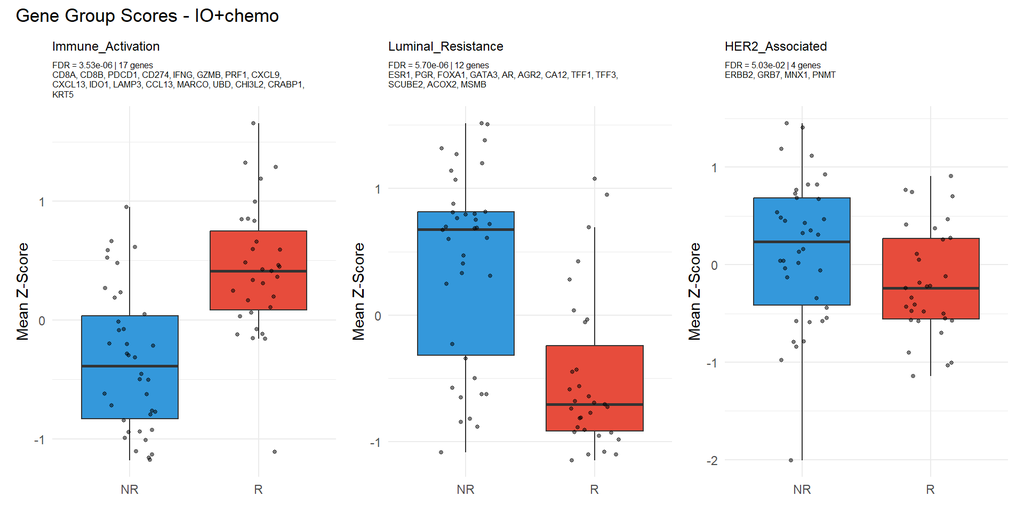

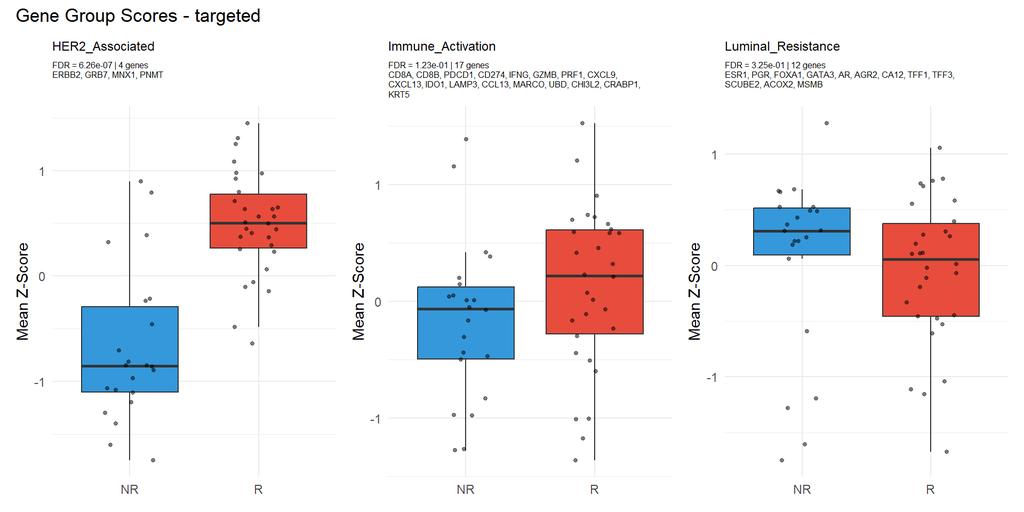

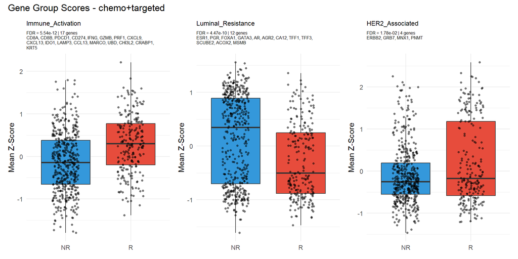

```r
write.csv(group_score_df,
          file = file.path(output_dir, "DEG_analysis", "gene_group_scores_vs_response.csv"),
          row.names = FALSE)

wrap_genes <- function(genes, width = 55) {
  stringr::str_wrap(paste(genes, collapse = ", "), width = width)
}

# Boxplots for gene groups (with gene names in subtitle)
for (treat in sub_treat) {
  treat_groups <- group_score_df %>% filter(Treatment == treat)
  if (nrow(treat_groups) == 0) next

  clin_sub <- clin_data[clin_data$treatment == treat, ]
  ids <- clin_sub$patientid[clin_sub$patientid %in% colnames(expr_data)]
  if (length(ids) < 2) next

  plot_list <- list()
  for (i in seq_len(nrow(treat_groups))) {
    gname <- treat_groups$Gene_Group[i]
    fdr_val <- treat_groups$FDR[i]
    genes <- gene_groups[[gname]]
    if (length(genes) < 2) next

    z_mat <- t(scale(t(expr_data[genes, ids, drop = FALSE])))
    df <- data.frame(
      Score = colMeans(z_mat, na.rm = TRUE),
      Response = clin_sub$response[match(ids, clin_sub$patientid)]
    )

    genes_txt <- wrap_genes(genes, width = 55)

    plot_list[[gname]] <- ggplot(df, aes(x = Response, y = Score, fill = Response)) +
      geom_boxplot(outlier.shape = NA) +
      geom_jitter(width = 0.2, alpha = 0.5, size = 1) +
      scale_fill_manual(values = c("R" = "#E74C3C", "NR" = "#3498DB")) +
      labs(
        title = gname,
        subtitle = paste0(
          "FDR = ", formatC(fdr_val, format = "e", digits = 2),
          " | ", length(genes), " genes\n",
          genes_txt
        ),
        y = "Mean Z-Score",
        x = NULL
      ) +
      theme_minimal() +
      theme(
        legend.position = "none",
        plot.subtitle = element_text(size = 6, lineheight = 0.95),
        plot.title = element_text(size = 9)
      )
  }

  if (length(plot_list) == 0) next

  combined <- wrap_plots(plot_list, ncol = 3) +
    plot_annotation(title = paste("Gene Group Scores -", treat))

  print(combined)
}
```

#### Step 3: PredictIO Signature Validation

Check which published IO signatures overlap with our candidate genes. This is **validation** — confirming that known signatures from other studies align with our findings.

```r
sig_candidate_overlap <- list()

for (file in rda_files) {
  sig_obj <- get(load(file))
  sig_name <- if ("signature_name" %in% colnames(sig_obj) && length(unique(sig_obj$signature_name)) > 0)
    unique(sig_obj$signature_name)[1]
  else
    tools::file_path_sans_ext(basename(file))

  if (!"gene_name" %in% colnames(sig_obj)) next

  genes <- sig_obj$gene_name
  matched <- intersect(candidate_genes, genes)

  if (length(matched) > 0) {
    sig_candidate_overlap[[sig_name]] <- data.frame(
      signature = sig_name,
      n_sig_genes = length(genes),
      n_candidate_overlap = length(matched),
      overlapping_genes = paste(sort(matched), collapse = ", ")
    )
  }
}

sig_overlap_df <- do.call(rbind, sig_candidate_overlap)
sig_overlap_df <- sig_overlap_df[order(-sig_overlap_df$n_candidate_overlap), ]

kable(sig_overlap_df, caption = "PredictIO Signatures Overlapping with Candidate Genes") %>%
  kable_styling(bootstrap_options = c("striped", "hover", "condensed"), full_width = FALSE) %>%
  scroll_box(height = "400px")
```

PredictIO Signatures Overlapping with Candidate Genes

|  | signature | n_sig_genes | n_candidate_overlap | overlapping_genes |
| --- | --- | --- | --- | --- |
| PTEN-MITF_Cabrita | PTEN-MITF_Cabrita | 263 | 13 | CCL5, CD38, CD8A, CXCL10, CXCL13, CXCL9, FOXC1, GBP5, GZMB, ROPN1, ROPN1B, SLC9A3R1, UBD |
| Response_Chen | Response_Chen | 443 | 11 | AIM2, CCL5, CD8A, CXCL9, GBP5, GNLY, GZMB, IL21R, PDCD1, PRF1, TCL1A |
| Inflammatory_Thompson | Inflammatory_Thompson | 27 | 10 | CCL5, CD274, CD8A, CXCL10, CXCL13, CXCL9, GZMB, IDO1, PDCD1, PRF1 |
| PredictIO_Bareche | PredictIO_Bareche | 100 | 10 | CD8A, CXCL10, CXCL13, CXCL9, GBP1, GBP5, GNLY, GZMB, PDCD1, PRF1 |
| COX-IS_Bonavita | COX-IS_Bonavita | 24 | 9 | CCL5, CD8A, CD8B, CXCL1, CXCL10, CXCL9, GZMB, IFNG, PRF1 |
| ImmunoScore_Hao | ImmunoScore_Hao | 76 | 9 | AIM2, CCL13, CCL5, CD38, CD8A, GPRC5C, IL21R, LAMP3, PDCD1 |
| IPS_Charoentong | IPS_Charoentong | 162 | 8 | AIM2, CCL5, CD274, CD8A, GNLY, IDO1, MARCO, PDCD1 |
| ImmuneScore_Roh | ImmuneScore_Roh | 41 | 7 | CCL5, CXCL10, CXCL9, GNLY, GZMB, IFNG, PRF1 |
| STAT1_Care | STAT1_Care | 39 | 7 | CXCL10, CXCL9, GBP1, GBP5, IDO1, IFNG, PRF1 |
| VIGex_Hernando-Calvo | VIGex_Hernando-Calvo | 12 | 7 | CD274, CXCL10, CXCL9, GZMB, IFNG, PDCD1, PRF1 |
| IRG_Ayers | IRG_Ayers | 17 | 5 | CCL5, CXCL10, CXCL13, GZMB, IDO1 |
| Teff-IFNG_Fehrenbacher | Teff-IFNG_Fehrenbacher | 8 | 5 | CD8A, CXCL10, CXCL9, GZMB, IFNG |
| TIS_Damotte | TIS_Damotte | 18 | 5 | CCL5, CD274, CD8A, CXCL9, IDO1 |
| Chemokine_Messina | Chemokine_Messina | 12 | 4 | CCL5, CXCL10, CXCL13, CXCL9 |
| IFN_Ayers | IFN_Ayers | 6 | 4 | CXCL10, CXCL9, IDO1, IFNG |
| Teff_McDermott | Teff_McDermott | 5 | 4 | CD274, CD8A, IFNG, PRF1 |
| CCL5-CXCL9_Dangaj | CCL5-CXCL9_Dangaj | 21 | 3 | CCL5, CD8A, CXCL9 |
| CD39-CD8Tcell_Chow | CD39-CD8Tcell_Chow | 23 | 3 | CXCL13, GNLY, PDCD1 |
| IMPRES_Auslander | IMPRES_Auslander | 28 | 3 | CD274, IDO1, PDCD1 |
| PDL1_Nishino | PDL1_Nishino | 3 | 2 | CD274, PDCD1 |
| Bcell_Budczies | Bcell_Budczies | 8 | 1 | TCL1A |
| Blood_Friedlander | Blood_Friedlander | 15 | 1 | ERBB2 |
| C-ECM_Chakravarthy | C-ECM_Chakravarthy | 58 | 1 | COL10A1 |
| CYT_Davoli | CYT_Davoli | 7 | 1 | PRF1 |
| CYT_Rooney | CYT_Rooney | 2 | 1 | PRF1 |
| EMT_Thompson | EMT_Thompson | 12 | 1 | CDH3 |
| ImmuneCells_Xiong | ImmuneCells_Xiong | 109 | 1 | MATN3 |
| IMS_Cui | IMS_Cui | 18 | 1 | CCL13 |
| M1_Hwang | M1_Hwang | 13 | 1 | LAMP3 |

Test if the overlapping subset of each PredictIO signature predicts response.

```r
sig_score_results <- list()

for (sig_name in names(sig_candidate_overlap)) {
  overlap_genes <- strsplit(sig_candidate_overlap[[sig_name]]$overlapping_genes, ", ")[[1]]
  overlap_genes <- overlap_genes[overlap_genes %in% rownames(expr_data)]

  if (length(overlap_genes) < 2) next

  for (treat in sub_treat) {
    clin_sub <- clin_data[clin_data$treatment == treat, ]
    ids <- clin_sub$patientid[clin_sub$patientid %in% colnames(expr_data)]

    sig_score <- colMeans(expr_data[overlap_genes, ids], na.rm = TRUE)
    response <- clin_sub$response[clin_sub$patientid %in% ids]

    wt <- wilcox.test(sig_score ~ response)

    sig_score_results[[paste(treat, sig_name)]] <- data.frame(
      Treatment = treat,
      Signature = sig_name,
      n_genes = length(overlap_genes),
      p_value = wt$p.value,
      mean_R = mean(sig_score[response == "R"], na.rm = TRUE),
      mean_NR = mean(sig_score[response == "NR"], na.rm = TRUE)
    )
  }
}

sig_score_df <- do.call(rbind, sig_score_results)
sig_score_df$FDR <- p.adjust(sig_score_df$p_value, method = "BH")
sig_score_df$Direction <- ifelse(sig_score_df$mean_R > sig_score_df$mean_NR, "Up in R", "Up in NR")
sig_score_df <- sig_score_df[order(sig_score_df$p_value), ]

kable(sig_score_df, caption = "PredictIO Overlap Scores vs Response (Validation)") %>%
  kable_styling(bootstrap_options = c("striped", "hover", "condensed"), full_width = FALSE) %>%
  scroll_box(height = "400px")
```

PredictIO Overlap Scores vs Response (Validation)

|  | Treatment | Signature | n_genes | p_value | mean_R | mean_NR | FDR | Direction |
| --- | --- | --- | --- | --- | --- | --- | --- | --- |
| chemo+targeted ImmunoScore_Hao | chemo+targeted | ImmunoScore_Hao | 9 | 0.0000000 | 9.069094 | 8.465876 | 0.0000000 | Up in R |
| chemo+targeted PTEN-MITF_Cabrita | chemo+targeted | PTEN-MITF_Cabrita | 13 | 0.0000000 | 10.187750 | 9.489410 | 0.0000000 | Up in R |
| chemo+targeted IRG_Ayers | chemo+targeted | IRG_Ayers | 5 | 0.0000000 | 10.074513 | 9.195577 | 0.0000000 | Up in R |
| chemo+targeted PredictIO_Bareche | chemo+targeted | PredictIO_Bareche | 10 | 0.0000000 | 9.613956 | 8.899824 | 0.0000000 | Up in R |
| chemo+targeted Inflammatory_Thompson | chemo+targeted | Inflammatory_Thompson | 10 | 0.0000000 | 9.471860 | 8.769437 | 0.0000000 | Up in R |
| chemo+targeted Chemokine_Messina | chemo+targeted | Chemokine_Messina | 4 | 0.0000000 | 10.605213 | 9.717338 | 0.0000000 | Up in R |
| chemo+targeted STAT1_Care | chemo+targeted | STAT1_Care | 7 | 0.0000000 | 9.596260 | 8.866370 | 0.0000000 | Up in R |
| chemo+targeted COX-IS_Bonavita | chemo+targeted | COX-IS_Bonavita | 9 | 0.0000000 | 9.004959 | 8.415566 | 0.0000000 | Up in R |
| chemo+targeted IPS_Charoentong | chemo+targeted | IPS_Charoentong | 8 | 0.0000000 | 9.006904 | 8.377037 | 0.0000000 | Up in R |
| chemo+targeted IFN_Ayers | chemo+targeted | IFN_Ayers | 4 | 0.0000000 | 9.892207 | 9.083886 | 0.0000000 | Up in R |
| chemo+targeted VIGex_Hernando-Calvo | chemo+targeted | VIGex_Hernando-Calvo | 7 | 0.0000000 | 8.853033 | 8.244870 | 0.0000000 | Up in R |
| chemo+targeted Teff-IFNG_Fehrenbacher | chemo+targeted | Teff-IFNG_Fehrenbacher | 5 | 0.0000000 | 9.670177 | 8.961008 | 0.0000000 | Up in R |
| chemo+targeted Response_Chen | chemo+targeted | Response_Chen | 11 | 0.0000000 | 9.445613 | 8.776668 | 0.0000000 | Up in R |
| chemo+targeted IMPRES_Auslander | chemo+targeted | IMPRES_Auslander | 3 | 0.0000000 | 8.878844 | 8.244332 | 0.0000000 | Up in R |
| chemo+targeted CD39-CD8Tcell_Chow | chemo+targeted | CD39-CD8Tcell_Chow | 3 | 0.0000000 | 8.914676 | 8.202309 | 0.0000000 | Up in R |
| chemo+targeted ImmuneScore_Roh | chemo+targeted | ImmuneScore_Roh | 7 | 0.0000000 | 9.149437 | 8.487379 | 0.0000000 | Up in R |
| chemo+targeted TIS_Damotte | chemo+targeted | TIS_Damotte | 5 | 0.0000000 | 9.886836 | 9.182796 | 0.0000000 | Up in R |
| chemo+targeted PDL1_Nishino | chemo+targeted | PDL1_Nishino | 2 | 0.0000000 | 8.099995 | 7.649734 | 0.0000000 | Up in R |
| chemo+targeted CCL5-CXCL9_Dangaj | chemo+targeted | CCL5-CXCL9_Dangaj | 3 | 0.0000000 | 10.650888 | 9.917162 | 0.0000000 | Up in R |
| chemo+targeted Teff_McDermott | chemo+targeted | Teff_McDermott | 4 | 0.0000000 | 7.272211 | 6.913485 | 0.0000000 | Up in R |
| IO+chemo PTEN-MITF_Cabrita | IO+chemo | PTEN-MITF_Cabrita | 13 | 0.0000007 | 10.607024 | 9.318835 | 0.0000019 | Up in R |
| IO+chemo IPS_Charoentong | IO+chemo | IPS_Charoentong | 8 | 0.0000184 | 9.255798 | 8.183656 | 0.0000502 | Up in R |
| IO+chemo ImmunoScore_Hao | IO+chemo | ImmunoScore_Hao | 9 | 0.0000358 | 9.131015 | 8.225054 | 0.0000935 | Up in R |
| IO+chemo IRG_Ayers | IO+chemo | IRG_Ayers | 5 | 0.0000403 | 10.557770 | 9.146734 | 0.0001008 | Up in R |
| IO+chemo ImmuneScore_Roh | IO+chemo | ImmuneScore_Roh | 7 | 0.0000453 | 9.440463 | 8.352004 | 0.0001088 | Up in R |
| IO+chemo IMPRES_Auslander | IO+chemo | IMPRES_Auslander | 3 | 0.0000539 | 9.042533 | 8.033178 | 0.0001224 | Up in R |
| IO+chemo COX-IS_Bonavita | IO+chemo | COX-IS_Bonavita | 9 | 0.0000571 | 9.249062 | 8.328901 | 0.0001224 | Up in R |
| IO+chemo STAT1_Care | IO+chemo | STAT1_Care | 7 | 0.0000571 | 9.919111 | 8.741359 | 0.0001224 | Up in R |
| IO+chemo CD39-CD8Tcell_Chow | IO+chemo | CD39-CD8Tcell_Chow | 3 | 0.0000678 | 9.015485 | 7.846077 | 0.0001402 | Up in R |
| IO+chemo Response_Chen | IO+chemo | Response_Chen | 11 | 0.0000717 | 9.640407 | 8.571082 | 0.0001434 | Up in R |
| IO+chemo PredictIO_Bareche | IO+chemo | PredictIO_Bareche | 10 | 0.0000802 | 9.832993 | 8.725701 | 0.0001553 | Up in R |
| IO+chemo IFN_Ayers | IO+chemo | IFN_Ayers | 4 | 0.0001182 | 10.408227 | 9.098423 | 0.0002148 | Up in R |
| IO+chemo VIGex_Hernando-Calvo | IO+chemo | VIGex_Hernando-Calvo | 7 | 0.0001182 | 9.068208 | 8.090344 | 0.0002148 | Up in R |
| IO+chemo Chemokine_Messina | IO+chemo | Chemokine_Messina | 4 | 0.0001390 | 11.021811 | 9.677960 | 0.0002453 | Up in R |
| IO+chemo Inflammatory_Thompson | IO+chemo | Inflammatory_Thompson | 10 | 0.0001548 | 9.743023 | 8.667300 | 0.0002653 | Up in R |
| IO+chemo Teff-IFNG_Fehrenbacher | IO+chemo | Teff-IFNG_Fehrenbacher | 5 | 0.0002016 | 10.042403 | 8.965707 | 0.0003361 | Up in R |
| IO+chemo TIS_Damotte | IO+chemo | TIS_Damotte | 5 | 0.0003046 | 10.164123 | 9.137759 | 0.0004940 | Up in R |
| IO+chemo PDL1_Nishino | IO+chemo | PDL1_Nishino | 2 | 0.0003726 | 7.966871 | 7.305591 | 0.0005883 | Up in R |
| IO+chemo CCL5-CXCL9_Dangaj | IO+chemo | CCL5-CXCL9_Dangaj | 3 | 0.0025674 | 10.902704 | 9.935605 | 0.0038511 | Up in R |
| IO+chemo Teff_McDermott | IO+chemo | Teff_McDermott | 4 | 0.0025674 | 7.300296 | 6.745846 | 0.0038511 | Up in R |
| targeted ImmuneScore_Roh | targeted | ImmuneScore_Roh | 7 | 0.0381336 | 9.059445 | 8.542185 | 0.0532096 | Up in R |
| targeted IPS_Charoentong | targeted | IPS_Charoentong | 8 | 0.0381336 | 8.779432 | 8.302615 | 0.0532096 | Up in R |
| targeted VIGex_Hernando-Calvo | targeted | VIGex_Hernando-Calvo | 7 | 0.0381336 | 8.759469 | 8.280111 | 0.0532096 | Up in R |
| targeted Teff-IFNG_Fehrenbacher | targeted | Teff-IFNG_Fehrenbacher | 5 | 0.0437817 | 9.598671 | 9.091604 | 0.0597023 | Up in R |
| targeted COX-IS_Bonavita | targeted | COX-IS_Bonavita | 9 | 0.0479191 | 8.887769 | 8.473765 | 0.0638922 | Up in R |
| targeted PredictIO_Bareche | targeted | PredictIO_Bareche | 10 | 0.0547252 | 9.514812 | 9.035766 | 0.0713807 | Up in R |
| targeted IFN_Ayers | targeted | IFN_Ayers | 4 | 0.0623024 | 9.654981 | 9.109364 | 0.0795350 | Up in R |
| targeted CD39-CD8Tcell_Chow | targeted | CD39-CD8Tcell_Chow | 3 | 0.0707097 | 8.883947 | 8.361698 | 0.0883871 | Up in R |
| targeted IMPRES_Auslander | targeted | IMPRES_Auslander | 3 | 0.0768051 | 8.631514 | 8.247411 | 0.0903589 | Up in R |
| targeted Inflammatory_Thompson | targeted | Inflammatory_Thompson | 10 | 0.0768051 | 9.343810 | 8.925311 | 0.0903589 | Up in R |
| targeted Response_Chen | targeted | Response_Chen | 11 | 0.0768051 | 9.391784 | 8.935644 | 0.0903589 | Up in R |
| targeted ImmunoScore_Hao | targeted | ImmunoScore_Hao | 9 | 0.0833137 | 9.011810 | 8.615116 | 0.0961312 | Up in R |
| targeted IRG_Ayers | targeted | IRG_Ayers | 5 | 0.0867285 | 9.853275 | 9.322295 | 0.0963650 | Up in R |
| targeted STAT1_Care | targeted | STAT1_Care | 7 | 0.0867285 | 9.361291 | 8.866400 | 0.0963650 | Up in R |
| targeted Chemokine_Messina | targeted | Chemokine_Messina | 4 | 0.0976413 | 10.482386 | 9.974715 | 0.1065178 | Up in R |
| targeted PDL1_Nishino | targeted | PDL1_Nishino | 2 | 0.1226710 | 8.012900 | 7.676832 | 0.1269010 | Up in R |
| targeted Teff_McDermott | targeted | Teff_McDermott | 4 | 0.1226710 | 7.209814 | 6.935402 | 0.1269010 | Up in R |
| targeted TIS_Damotte | targeted | TIS_Damotte | 5 | 0.1226710 | 9.735631 | 9.373896 | 0.1269010 | Up in R |
| targeted PTEN-MITF_Cabrita | targeted | PTEN-MITF_Cabrita | 13 | 0.1633471 | 9.733640 | 9.494050 | 0.1661157 | Up in R |
| targeted CCL5-CXCL9_Dangaj | targeted | CCL5-CXCL9_Dangaj | 3 | 0.2896220 | 10.607634 | 10.269589 | 0.2896220 | Up in R |

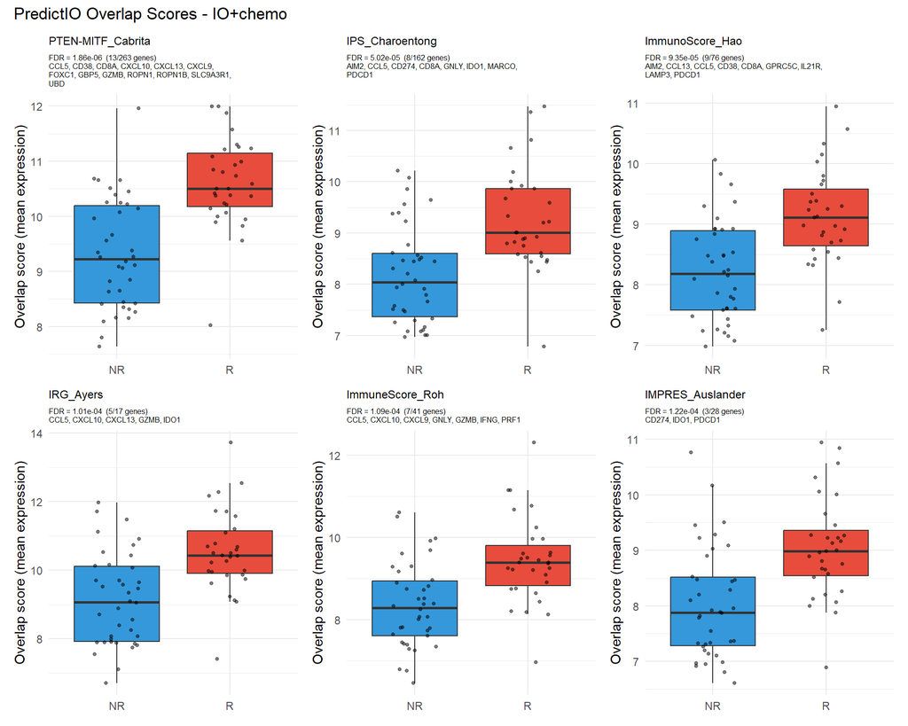

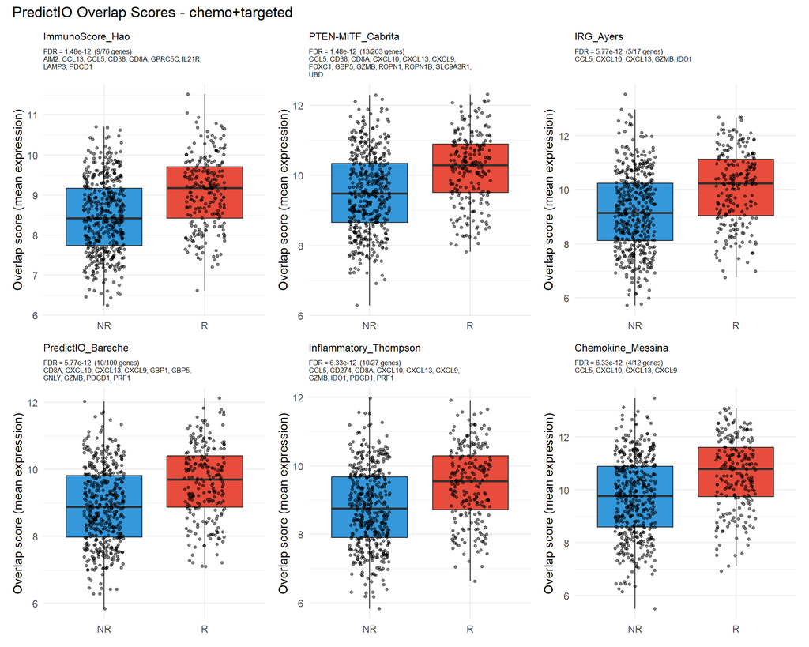

```r
# add gene names
wrap_genes <- function(genes, width = 45) {
  stringr::str_wrap(paste(genes, collapse = ", "), width = width)
}

# helper: wrap long gene lists nicely
wrap_genes <- function(genes, width = 45) {
  stringr::str_wrap(paste(genes, collapse = ", "), width = width)
}

for (treat in sub_treat) {

  top_sigs_treat <- sig_score_df %>%
    filter(Treatment == treat, FDR < 0.05) %>%
    arrange(FDR) %>%
    head(6)

  if (nrow(top_sigs_treat) == 0) next

  clin_sub <- clin_data[clin_data$treatment == treat, ]
  ids <- clin_sub$patientid[clin_sub$patientid %in% colnames(expr_data)]
  if (length(ids) < 2) next

  plot_list <- list()

  for (i in seq_len(nrow(top_sigs_treat))) {
    sig_name <- top_sigs_treat$Signature[i]
    fdr_val <- top_sigs_treat$FDR[i]

    n_total <- sig_candidate_overlap[[sig_name]]$n_sig_genes

    overlap_genes <- strsplit(sig_candidate_overlap[[sig_name]]$overlapping_genes, ",\\s*")[[1]]
    overlap_genes <- overlap_genes[overlap_genes %in% rownames(expr_data)]
    n_used <- length(overlap_genes)

    if (n_used < 2) next

    df <- data.frame(
      Score = colMeans(expr_data[overlap_genes, ids, drop = FALSE], na.rm = TRUE),
      Response = clin_sub$response[match(ids, clin_sub$patientid)]
    )

    genes_txt <- wrap_genes(overlap_genes, width = 45)

    plot_list[[sig_name]] <- ggplot(df, aes(x = Response, y = Score, fill = Response)) +
      geom_boxplot(outlier.shape = NA) +
      geom_jitter(width = 0.2, alpha = 0.5, size = 1) +
      scale_fill_manual(values = c("R" = "#E74C3C", "NR" = "#3498DB")) +
      labs(
        title = sig_name,
        subtitle = paste0(
          "FDR = ", formatC(fdr_val, format = "e", digits = 2),
          "  (", n_used, "/", n_total, " genes)\n",
          genes_txt
        ),
        y = "Overlap score (mean expression)",
        x = NULL
      ) +
      theme_minimal() +
      theme(
        legend.position = "none",
        plot.title = element_text(size = 9),
        plot.subtitle = element_text(size = 6, lineheight = 0.95)
      )
  }

  if (length(plot_list) == 0) next

  combined <- wrap_plots(plot_list, ncol = 3) +
    plot_annotation(title = paste("PredictIO Overlap Scores -", treat))

  print(combined)
}
```

#### Step 4: Heatmaps

Heatmap of the top 20 significant genes (FDR < 0.05) from gene-response correlation, clustered by expression pattern (ward.D2). Columns are patients, rows are genes, expression is z-score scaled.

**Column annotations:**

- **Response**: pathological complete response (R) vs residual disease (NR)
- **Receptor**: hormone receptor and HER2 status (TN, HR+HER2-, HR+HER2+, HR-HER2+)

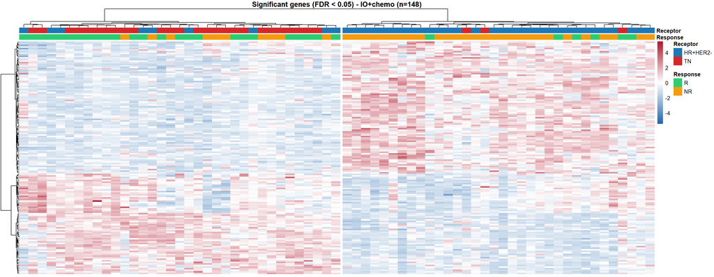

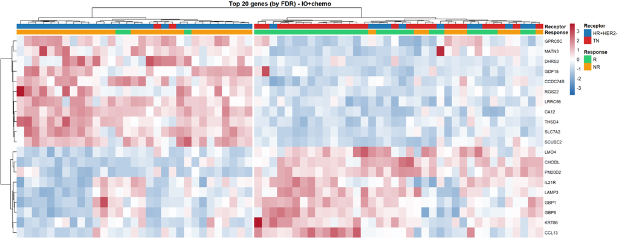

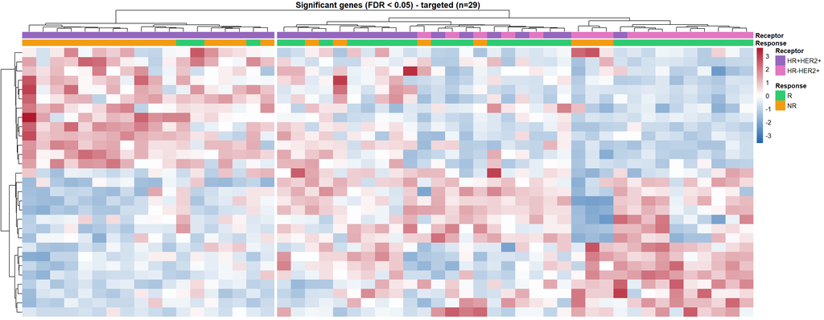

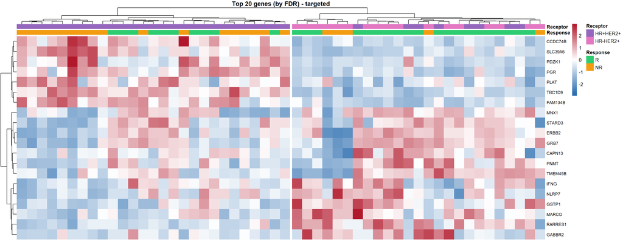

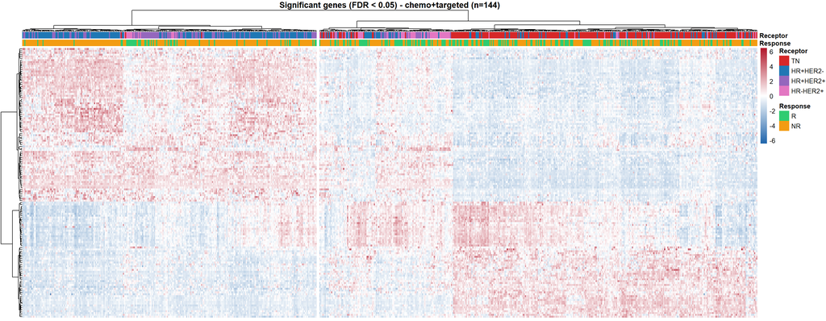

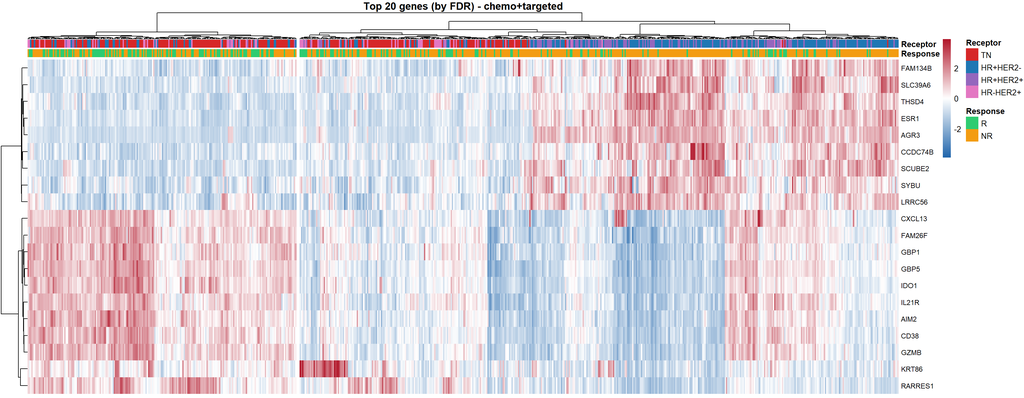

```r
for (treat in sub_treat) {

  # -------------------------
  # 1) ALL significant genes
  # -------------------------
  sig_genes <- gene_response_df %>%
    filter(Treatment == treat, FDR < 0.05) %>%
    arrange(FDR) %>%
    pull(Gene) %>%
    unique()

  if (length(sig_genes) < 2) next

  top20_genes <- head(sig_genes, 20)

  clin_sub <- clin_data[clin_data$treatment == treat, ]
  ids <- clin_sub$patientid[clin_sub$patientid %in% colnames(expr_data)]
  if (length(ids) < 2) next

  # -------------------------
  # Annotations (match order)
  # -------------------------
  annot_col <- data.frame(
    Response = clin_sub$response[match(ids, clin_sub$patientid)],
    row.names = ids
  )

  annot_colors <- list(
    Response = c("R" = "#2ECC71", "NR" = "#F39C12")
  )

  if ("Receptor.Subtype" %in% colnames(clin_sub)) {
    vals <- clin_sub$Receptor.Subtype[match(ids, clin_sub$patientid)]
    if (sum(!is.na(vals)) > 0) {
      annot_col$Receptor <- vals
      annot_colors$Receptor <- c(
        "TN" = "#D62728", "HR+HER2-" = "#1F77B4",
        "HR+HER2+" = "#9467BD", "HR-HER2+" = "#E377C2"
      )[unique(na.omit(vals))]
    }
  }

  # -------------------------
  # Matrices
  # -------------------------
  mat_all <- expr_data[sig_genes, ids, drop = FALSE]
  mat_top20 <- expr_data[top20_genes, ids, drop = FALSE]

  # -------------------------
  # Heatmap A: ALL genes
  # -------------------------
  pheatmap(mat_all,
    annotation_col = annot_col,
    annotation_colors = annot_colors,
    scale = "row",
    show_colnames = FALSE,
    show_rownames = FALSE,
    main = paste0("Significant genes (FDR < 0.05) - ", treat, " (n=", length(sig_genes), ")"),
    clustering_method = "ward.D2",
    color = colorRampPalette(c("#2166AC", "white", "#B2182B"))(100),
    border_color = NA,
    fontsize = 10,
    treeheight_col = 30,
    treeheight_row = 30,
    cutree_cols = 2
  )

  # -------------------------
  # Heatmap B: TOP 20 genes
  # -------------------------
  pheatmap(mat_top20,
    annotation_col = annot_col,
    annotation_colors = annot_colors,
    scale = "row",
    show_colnames = FALSE,
    show_rownames = TRUE,
    fontsize_row = 9,
    main = paste0("Top 20 genes (by FDR) - ", treat),
    clustering_method = "ward.D2",
    color = colorRampPalette(c("#2166AC", "white", "#B2182B"))(100),
    border_color = NA,
    fontsize = 10,
    treeheight_col = 30,
    treeheight_row = 30,
    cutree_cols = 2
  )
}
```

### 9. Full PredictIO Signature Scoring

```r
# TODO: Implement PredictioR-based signature scoring per treatment arm
# TODO: Confirm/control group mapping (e.g., Paclitaxel arms as control)
# TODO: PredictIO signatures are IO-focused and largely pan-cancer
```

## Section 3: Radiomics Analysis

Process MRI-derived radiomic features to identify imaging biomarkers associated with treatment response, and prepare features for radiogenomic integration.

### 1. Load & Clean Radiomic Features

Check how many patients, how many features

```r
# Load radiomics features
ISPY_radiomics  <- read.csv(file.path(here(), "data/results/radiomics/TCIA_ISPY2_feature_extracted_v1.csv"))
ACRIN_radiomics <- read.csv(file.path(here(), "data/results/radiomics/TCIA_ACRIN-6698_feature_extracted.csv"))
# missing_radiomics <- read.csv(file.path(here(), "data/results/radiomics/missing_samples.csv"))

# Combine radiomics
full_radiomics <- bind_rows(ISPY_radiomics, ACRIN_radiomics)

# Check for all-NA rows
feature_cols <- grep("^original", colnames(full_radiomics), value = TRUE)
all_na_rows <- rowSums(!is.na(full_radiomics[, feature_cols])) == 0
cat("All-NA feature rows:", sum(all_na_rows), "\n")
```

All-NA feature rows: 0

```r
# Load index files
ispy_index  <- read.csv(file.path(here(), "data/procdata/radiomics/ISPY2/mit_ISPY2_index.csv"))
acrin_index <- read.csv(file.path(here(), "data/procdata/radiomics/ISPY2/mit_ACRIN-6698_index.csv"))
common_cols <- intersect(names(ispy_index), names(acrin_index))
for (col in common_cols) {
  if (class(ispy_index[[col]]) != class(acrin_index[[col]])) {
    ispy_index[[col]] <- as.character(ispy_index[[col]])
    acrin_index[[col]] <- as.character(acrin_index[[col]])
  }
}
full_index <- bind_rows(ispy_index, acrin_index)

# Extract SampleID from filepath
full_index$SampleID <- str_extract(full_index$filepath, "^[^/]+")
tp_lookup <- full_index %>%
  filter(Modality == "MR") %>%
  select(SampleID, PatientID, AcquisitionDate) %>%
  distinct() %>%
  group_by(PatientID) %>%
  arrange(AcquisitionDate) %>%
  mutate(TIME_POINT = paste0("T", row_number() - 1)) %>%
  ungroup()

# Join TIME_POINT to radiomics
full_radiomics <- full_radiomics %>%
  left_join(tp_lookup %>% select(SampleID, PatientID, TIME_POINT),
            by = c("patientid" = "SampleID"))

# Add patient_base for clinical merge
full_radiomics$patient_base <- gsub("^ISPY2-|^ACRIN-6698-", "", gsub("_.*", "", full_radiomics$patientid))

# Check
cat("TIME_POINT distribution:\n"); print(table(full_radiomics$TIME_POINT, useNA = "ifany"))
```

TIME_POINT distribution:

T0 T1 T2 T3 985 951 869 721

```r
radiogenomic_patients <- intersect(full_radiomics$patient_base, merged_clin$patientid)
cat("Radiogenomic cohort:", length(radiogenomic_patients), "patients\n")
```

Radiogenomic cohort: 982 patients

```r
# Keep only overlapping patients
full_radiomics <- full_radiomics %>% filter(patient_base %in% radiogenomic_patients)
merged_clin <- merged_clin %>% filter(patientid %in% radiogenomic_patients)

kable(head(full_radiomics[, c("patientid", "patient_base", "PatientID", "TIME_POINT", feature_cols[1:5])], 10),
      caption = "Radiomic Features") %>%
  kable_styling(bootstrap_options = c("striped", "hover", "condensed"), full_width = FALSE) %>%
  scroll_box(height = "400px", width = "100%")
```

Radiomic Features

| patientid | patient_base | PatientID | TIME_POINT | original_shape_VoxelVolume | original_shape_MeshVolume | original_shape_SurfaceArea | original_shape_SurfaceVolumeRatio | original_shape_Compactness1 |
| --- | --- | --- | --- | --- | --- | --- | --- | --- |
| ISPY2-100899_0000 | 100899 | ISPY2-100899 | T3 | 54 | 27.250000 | 126.14116 | 4.629034 | 0.0108519 |
| ISPY2-100899_0001 | 100899 | ISPY2-100899 | T1 | 661 | 448.875000 | 1459.47070 | 3.251397 | 0.0045421 |
| ISPY2-100899_0002 | 100899 | ISPY2-100899 | T0 | 449 | 323.333333 | 954.79292 | 2.952968 | 0.0061832 |
| ISPY2-100899_0003 | 100899 | ISPY2-100899 | T2 | 200 | 124.291667 | 455.50059 | 3.664772 | 0.0072133 |
| ISPY2-102011_0004 | 102011 | ISPY2-102011 | T1 | 14 | 6.333333 | 34.59662 | 5.462624 | 0.0175593 |
| ISPY2-102011_0005 | 102011 | ISPY2-102011 | T0 | 512 | 398.166667 | 989.95005 | 2.486270 | 0.0072122 |
| ISPY2-102011_0006 | 102011 | ISPY2-102011 | T3 | 16 | 7.583333 | 39.29107 | 5.181240 | 0.0173718 |
| ISPY2-102011_0007 | 102011 | ISPY2-102011 | T2 | 78 | 51.166667 | 191.04050 | 3.733691 | 0.0109326 |
| ISPY2-103693_0008 | 103693 | ISPY2-103693 | T2 | 253 | 199.375000 | 538.82256 | 2.702558 | 0.0089935 |
| ISPY2-103693_0009 | 103693 | ISPY2-103693 | T1 | 598 | 547.750000 | 947.36533 | 1.729558 | 0.0105982 |

```r
kable(head(merged_clin, 10), caption = "Clinical Data") %>%
  kable_styling(bootstrap_options = c("striped", "hover", "condensed"), full_width = FALSE) %>%
  scroll_box(height = "400px", width = "100%")
```

Clinical Data

| patientid | sex | age | cancer_type | histo | tissueid | stage | response.other.info | recist | response | treatment | dna | rna | survival_time_pfs | event_occurred_pfs | survival_time_os | event_occurred_os | survival_unit | survival_type | TMB_raw | nsTMB_raw | indel_TMB_raw | indel_nsTMB_raw | TMB_perMb | nsTMB_perMb | indel_TMB_perMb | indel_nsTMB_perMb | CIN | CNA_tot | AMP | … |
| --- | --- | --- | --- | --- | --- | --- | --- | --- | --- | --- | --- | --- | --- | --- | --- | --- | --- | --- | --- | --- | --- | --- | --- | --- | --- | --- | --- | --- | --- | --- |
| 100899 | F | NA | Breast | NA | Breast | NA | NR | NA | NR | chemo+targeted | NA | microarray | NA | NA | NA | NA | NA | None | NA | NA | NA | NA | NA | NA | NA | NA | NA | NA | NA | … |
| 102011 | F | NA | Breast | NA | Breast | NA | NR | NA | NR | chemo+targeted | NA | microarray | NA | NA | NA | NA | NA | None | NA | NA | NA | NA | NA | NA | NA | NA | NA | NA | NA | … |
| 102212 | F | NA | Breast | NA | Breast | NA | NR | NA | NR | chemo+targeted | NA | microarray | NA | NA | NA | NA | NA | None | NA | NA | NA | NA | NA | NA | NA | NA | NA | NA | NA | … |
| 103693 | F | NA | Breast | NA | Breast | NA | NR | NA | NR | IO+chemo | NA | microarray | NA | NA | NA | NA | NA | None | NA | NA | NA | NA | NA | NA | NA | NA | NA | NA | NA | … |
| 103939 | F | NA | Breast | NA | Breast | NA | NR | NA | NR | chemo | NA | microarray | NA | NA | NA | NA | NA | None | NA | NA | NA | NA | NA | NA | NA | NA | NA | NA | NA | … |
| 104268 | F | NA | Breast | NA | Breast | NA | NR | NA | NR | chemo | NA | microarray | NA | NA | NA | NA | NA | None | NA | NA | NA | NA | NA | NA | NA | NA | NA | NA | NA | … |
| 104384 | F | NA | Breast | NA | Breast | NA | NR | NA | NR | IO+chemo | NA | microarray | NA | NA | NA | NA | NA | None | NA | NA | NA | NA | NA | NA | NA | NA | NA | NA | NA | … |
| 105286 | F | NA | Breast | NA | Breast | NA | NR | NA | NR | chemo+targeted | NA | microarray | NA | NA | NA | NA | NA | None | NA | NA | NA | NA | NA | NA | NA | NA | NA | NA | NA | … |
| 105513 | F | NA | Breast | NA | Breast | NA | R | NA | R | chemo+targeted | NA | microarray | NA | NA | NA | NA | NA | None | NA | NA | NA | NA | NA | NA | NA | NA | NA | NA | NA | … |
| 107700 | F | NA | Breast | NA | Breast | NA | NR | NA | NR | chemo+targeted | NA | microarray | NA | NA | NA | NA | NA | None | NA | NA | NA | NA | NA | NA | NA | NA | NA | NA | NA | … |

### 2. Select T0 (Baseline)

Filter to earliest timepoint per patient This is your baseline radiomic profile

- **T0 baseline** for all patients
- **Delta-radiomics** for patients with T0 + T1
- **Volume change** visualization by response
- **Features correlated with volume** (expected, less interesting)
- **Features NOT correlated with volume** (interesting — correlate these with genomics next)

```r
# Samples per patient
radiomics_feature <- full_radiomics
samples_per_pt <- table(radiomics_feature$patient_base)
cat("Samples per patient:\n"); print(table(samples_per_pt))
```

Samples per patient: samples_per_pt 1 2 3 4 28 76 174 704

```r
# Verify existing timepoints
cat("TIME_POINT distribution:\n")
```

TIME_POINT distribution:

```r
table(radiomics_feature$TIME_POINT)
```

T0 T1 T2 T3 982 949 867 720

```r
# Select T0 (baseline)
radiomics_T0 <- radiomics_feature %>% filter(TIME_POINT == "T0")

# Patients with T0 + T1 (for delta-radiomics)
pts_T0 <- unique(radiomics_feature$patient_base[radiomics_feature$TIME_POINT == "T0"])
pts_T1 <- unique(radiomics_feature$patient_base[radiomics_feature$TIME_POINT == "T1"])
cat("Patients with T0 + T1 (for delta-radiomics):", length(intersect(pts_T0, pts_T1)), "\n")
```

Patients with T0 + T1 (for delta-radiomics): 949

### 3. Delta-Radiomics (T1 − T0)

delta = T1 value - T0 value

```r
# Select patients with both T0 and T1
radiomics_T1 <- radiomics_feature %>% filter(TIME_POINT == "T1")

delta_patients <- intersect(radiomics_T0$patient_base, radiomics_T1$patient_base)
cat("Patients with both T0 and T1:", length(delta_patients), "\n")
```

Patients with both T0 and T1: 949

```r
# Calculate T1 - T0 for each feature
T0_mat <- radiomics_T0 %>% filter(patient_base %in% delta_patients) %>% arrange(patient_base)
T1_mat <- radiomics_T1 %>% filter(patient_base %in% delta_patients) %>% arrange(patient_base)

delta_radiomics <- T1_mat[, feature_cols] - T0_mat[, feature_cols]
delta_radiomics$patient_base <- T0_mat$patient_base
cat("Volume change - Min:", min(delta_radiomics$volume_change),
    "| Max:", max(delta_radiomics$volume_change),
    "| Mean:", round(mean(delta_radiomics$volume_change), 1),
    "| SD:", round(sd(delta_radiomics$volume_change), 1), "\n")
```

Volume change - Min: Inf | Max: -Inf | Mean: NA | SD: NA

```r
cat("Delta-radiomics matrix:", nrow(delta_radiomics), "patients x", length(feature_cols), "features\n")
```

Delta-radiomics matrix: 949 patients x 108 features

```r
DT::datatable(delta_radiomics)
```

[output not shown]

[output cut: 939 more lines]

Volume change alone (T1 − T0) is not a strong predictor of response this early

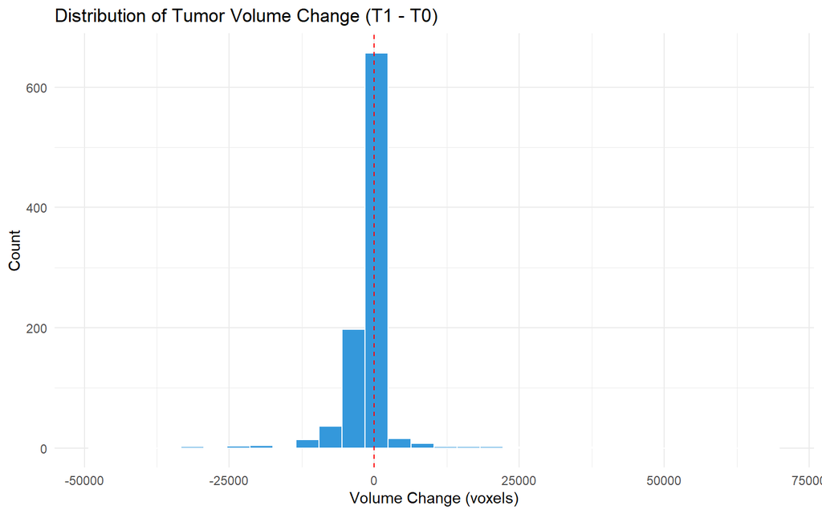

```r
# Visualize change in volume (VoxelVolume)
delta_radiomics$volume_change <- delta_radiomics$original_shape_VoxelVolume

ggplot(delta_radiomics, aes(x = volume_change)) +
  geom_histogram(bins = 30, fill = "#3498DB", color = "white") +
  geom_vline(xintercept = 0, linetype = "dashed", color = "red") +
  labs(title = "Distribution of Tumor Volume Change (T1 - T0)",
       x = "Volume Change (voxels)", y = "Count") +
  theme_minimal()
```

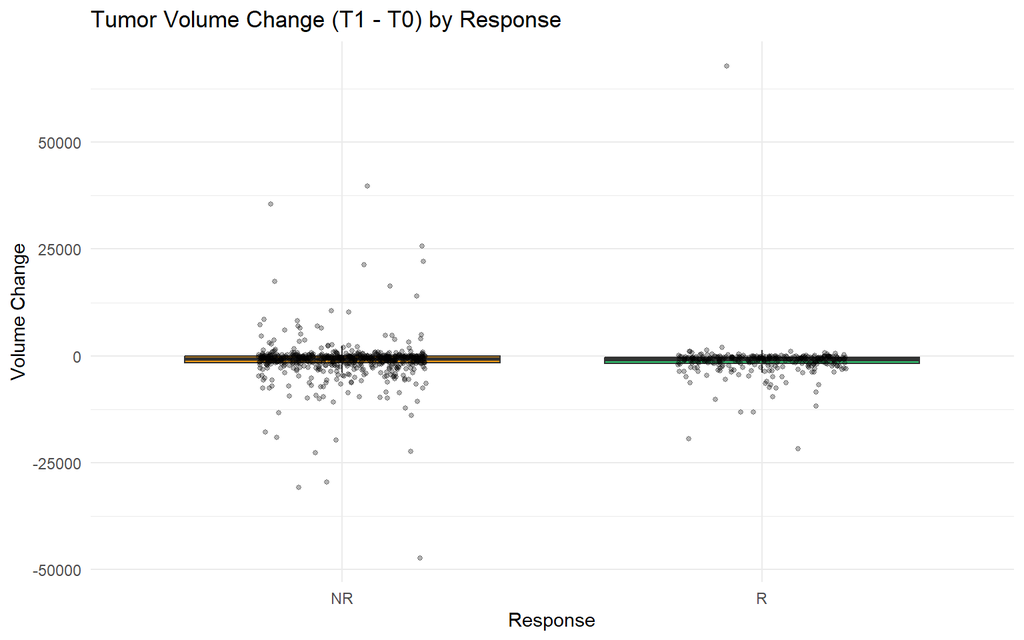

```r
# Volume change by response
delta_with_clin <- merge(delta_radiomics, merged_clin[, c("patientid", "response", "treatment")],
                          by.x = "patient_base", by.y = "patientid")

ggplot(delta_with_clin, aes(x = response, y = volume_change, fill = response)) +
  geom_boxplot(outlier.shape = NA) +
  geom_jitter(width = 0.2, alpha = 0.3, size = 1) +
  scale_fill_manual(values = c("R" = "#2ECC71", "NR" = "#F39C12")) +
  labs(title = "Tumor Volume Change (T1 - T0) by Response",
       x = "Response", y = "Volume Change") +
  theme_minimal() +
  theme(legend.position = "none")
```

```r
# Check extreme outliers
vol_threshold <- mean(delta_radiomics$volume_change) + 3 * sd(delta_radiomics$volume_change)
cat("Outlier threshold (3 SD):", round(vol_threshold), "\n")
```

Outlier threshold (3 SD): 13368

```r
outliers <- delta_with_clin %>% filter(abs(volume_change) > abs(vol_threshold))
cat("Outliers:", nrow(outliers), "\n")
```

Outliers: 20

```r
print(outliers[, c("patient_base", "volume_change", "response")])
```

patient_base volume_change response 1 201873 -19417 R 2 262131 -47225 NR 3 357017 -30709 NR 4 373672 -19054 NR 5 402384 13991 NR 6 427321 -21751 R 7 443708 25704 NR 8 494022 -22733 NR 9 521860 -19752 NR 10 527320 39658 NR 11 559021 67851 R 12 597873 35563 NR 13 601489 -29466 NR 14 622315 16334 NR 15 628823 21327 NR 16 663467 22120 NR 17 735673 -17856 NR 18 781335 -13928 NR 19 786480 -22391 NR 20 849605 17494 NR

```r
# Correlate each feature change with volume change
vol_cor <- sapply(feature_cols, function(f) {
  cor(delta_radiomics[[f]], delta_radiomics$volume_change, use = "complete.obs")
})

vol_cor_df <- data.frame(
  Feature = names(vol_cor),
  Correlation = vol_cor,
  Abs_Correlation = abs(vol_cor)
) %>% arrange(desc(Abs_Correlation))

# Features highly correlated with volume (|r| > 0.7)
cat("Features highly correlated with volume (|r| > 0.7):", sum(vol_cor_df$Abs_Correlation > 0.7), "\n")
```

Features highly correlated with volume (|r| > 0.7): 7

```r
# Features NOT correlated with volume (|r| < 0.3) - interesting for genomics
cat("Features independent of volume (|r| < 0.3):", sum(vol_cor_df$Abs_Correlation < 0.3), "\n")
```

Features independent of volume (|r| < 0.3): 91

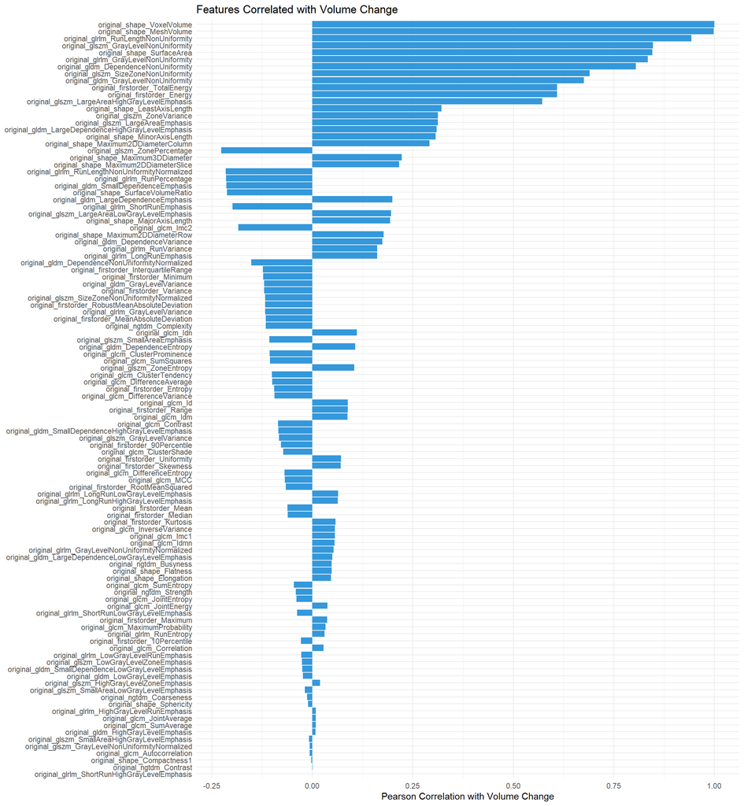

```r
ggplot(vol_cor_df, aes(x = reorder(Feature, Abs_Correlation), y = Correlation)) +
  geom_col(fill = "#3498DB") +
  coord_flip() +
  labs(title = "Features Correlated with Volume Change",
       x = NULL, y = "Pearson Correlation with Volume Change") +
  theme_minimal()
```

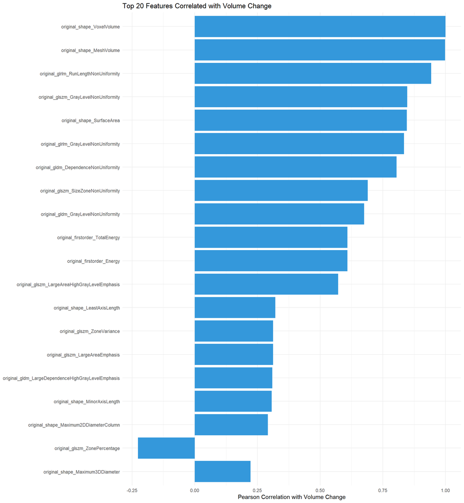

```r
# Plot top 20 correlated features
ggplot(head(vol_cor_df, 20), aes(x = reorder(Feature, Abs_Correlation), y = Correlation)) +
  geom_col(fill = "#3498DB") +
  coord_flip() +
  labs(title = "Top 20 Features Correlated with Volume Change",
       x = NULL, y = "Pearson Correlation with Volume Change") +
  theme_minimal()
```

```r
# Plot features NOT correlated with volume
independent_features <- vol_cor_df %>% filter(Abs_Correlation < 0.3)
cat("\nVolume-independent features (candidates for genomic correlation):\n")
```

Volume-independent features (candidates for genomic correlation):

R version 4.4.1 (2024-06-14 ucrt) Platform: x86_64-w64-mingw32/x64 Running under: Windows 11 x64 (build 26200)

Matrix products: default

locale: [1] LC_COLLATE=English_United States.utf8 [2] LC_CTYPE=English_United States.utf8  
[3] LC_MONETARY=English_United States.utf8 [4] LC_NUMERIC=C  
[5] LC_TIME=English_United States.utf8

time zone: America/New_York tzcode source: internal

attached base packages: [1] grid stats4 stats graphics grDevices utils datasets [8] methods base

other attached packages: [1] pheatmap_1.0.12 stringr_1.5.1  
[3] patchwork_1.3.2 fgsea_1.30.0  
[5] msigdbr_24.1.0 EnhancedVolcano_1.22.0  
[7] ggrepel_0.9.6 limma_3.60.6  
[9] kableExtra_1.4.0 ggvenn_0.1.10  
[11] tidyr_1.3.2 dplyr_1.2.0  
[13] ggplot2_4.0.2 readxl_1.4.5  
[15] knitr_1.50 MultiAssayExperiment_1.30.3 [17] SummarizedExperiment_1.34.0 Biobase_2.64.0  
[19] GenomicRanges_1.56.2 GenomeInfoDb_1.40.1  
[21] IRanges_2.38.1 S4Vectors_0.42.1  
[23] BiocGenerics_0.50.0 MatrixGenerics_1.16.0  
[25] matrixStats_1.4.1 here_1.0.1

3. Quality Check

Filter out small/failed segmentations Check for missing values Check how many patients overlap with genomics (982)

4. Delta-Radiomics (T1 − T0)

Filter patients with both T0 and T1 Calculate T1 minus T0 for each feature Visualize volume change Identify features correlated with volume Identify features NOT correlated with volume (interesting ones)

5. Correlate Radiomics with Response

Test each radiomic feature vs R/NR per treatment Similar to gene-response correlation in Section 8

6. READII (later)

Negative control images Extract same features